# Climate Vulnerability Indicators for Salmon: A Quantitative Framework for Evaluating the Relative Vulnerability of Pacific Salmon Conservation Units

DRAFT - not for further distribution without permission of the authors

Cory Lagasse, Josie Iacarella, Colin Bailey, Michael Arbeider

21 November 2025

# Introduction

Climate change is having profound effects on Pacific salmon populations throughout their range, contributing to the declines of many stocks while introducing greater variability and uncertainty into assessments and planning (**macdonald2023?**; Crozier et al. 2019). Although the significance of climate change for Pacific salmon is well established, its effects have been and will continue to be variable for the 5 species, 69 stock management units (SMUs) and over 450 conservations units (CUs) of Pacific salmon in Canada. The salmonscape of the future will be different than the past, with serious implications for the people, societies, and ecosystems of which salmon are an integral part.

A wealth of scientific research informs our understanding of future changes to freshwater and marine ecosystems, and how Pacific salmon are likely to respond to those changes (Crozier and Siegel 2023). While many of the mechanisms of climate change vulnerability are understood, at least a conceptual level, there are few broad-scale assessments that evaluate the relative or absolute climate vulnerability of Pacific salmon across multiple species and wide geographic areas (e.g. Crozier et al. 2019). This gap is particularly notable across the Canadian distribution of Pacific salmon, which spans from the southern to the northern half of their range and includes a great diversity of life history types and ecosystems.

Vulnerability assessments can help bridge the gap between our scientific understanding and application towards resource management decisions and planning. Pacific salmon are a vitally important species, resource, and symbol within Canada, and in recent years have been the target of hundreds of millions of dollars in investments to support stock rebuilding, habitat restoration, fisheries monitoring, and hatchery enhancement. The success of these activities will be influenced by climate changes, which may lead to further declines in productivity for some stocks or outweigh the positive influences of rebuilding work. While there are many factors to be considered in prioritizing investments and making resource management decisions for Pacific salmon, assessment frameworks that are scientifically robust, transparent, and reproducible are more likely to be trusted and facilitate the incorporation of climate change considerations into decision-making (Boyce et al. 2022; Rangwala et al. 2021).

In this report, we present an indicator-based approach for assessing climate change risk factors across the Pacific salmon life-cycle. The framework incorporates recently developed, downscaled climate models in marine and freshwater domains (Weller, Moore, and Iacarella 2024; Peña and Fine 2024), cumulative habitat stressors models (CSAS 2024; Murray et al. 2024), population status assessments (**csas2024a?**), life history timing (Wilson and Peacock 2025), and environmental niche models (Josephine C. Iacarella and Weller 2023) into 17 quantitative indicators. The indicators are grounded in ecological theory and represent biological mechanisms of climate change responses, including demographics, physiology, and genetic adaptation (Urban et al. 2016; Pacifici et al. 2015; Boyce et al. 2022).

We apply the climate vulnerability indicators for salmon (CVIS) framework to 5 species and 50 CUs of Pacific salmon within the Fraser River basin, an area of high life history diversity with variation in recent responses to climate change. Climate change is recognized as a prime threat to many populations within the Fraser basin, particularly for Fraser River sockeye and Interior Fraser Chinook, however, to date most assessments of climate vulnerability have focused on specific CUs, species, or watersheds (Doutaz et al. 2023; Dionne et al. 2023). Furthermore, many threats assessments and other attempts to evaluate climate vulnerability have been centered around expert judgement and categorical traits, limiting comparability across assessments.

By quantifying multiple mechanisms of climate vulnerability across a large basin, we aim to better understand differences in climate change risk at the individual CU, species, and basin level. In particular, we investigate which CUs are most likely to be at risk from climate change during their freshwater rearing, upstream migration, and nearshore marine life stages, and which factors are most important in differentiating that risk among CUs and species. We also quantify the sensitivity of risk rankings across different time periods (mid-century versus end-of-century), emissions scenarios, global climate models, and scoring frameworks to understand the influence of different methods and objectives for assessment. Ultimately, our framework provides a means for identifying patterns of climate change vulnerability across spatial areas and demographic units, and testing the sensitivity of those patterns to different models and assumptions to help identify the drivers of climate vulnerability.

# Methods Overview

The CVIS framework consists of 17 quantitative indicators (Table 1) classified into five categories based on mechanism and life-stage: freshwater spawning and rearing, upstream migration, nearshore marine, demographics, and genetics. Every indicator uses a quantitative metric, such as the mean stream temperature or percent change in flow, to summarize the riskrepresent risk. The indicator approach allows for flexibility in inputs and metrics of risk; various model types can be used to derive statistical summaries of risk depending on the mechanism to assess. Variation and uncertainty in indicator values are represented using 80% quantile ranges of global climate models where relevant.

Table 1 - Vulnerability Indicators

| Abbreviation | Category | Description |
| --- | --- | --- |
| favchange | Freshwater Spawning and Rearing | ENM Change in Favourability |
| CT | Freshwater Spawning and Rearing | Cumulative threats to freshwater habitat |
| tw8rate | Freshwater Spawning and Rearing | Rate of change in August Temperature |
| tw8proj | Freshwater Spawning and Rearing | Projected August Temperature |
| lowQpdelta | Freshwater Spawning and Rearing | Proportional change in August flow (stream model) |
| highQpdelta | Freshwater Spawning and Rearing | Proportional change in Nov-Jan flow (stream model) |
| fwres | Freshwater Spawning and Rearing | Freshwater residency time |
| migrT | Upstream Migration | Projected temperature during upstream migration |
| migrQ | Upstream Migration | Proportional change in discharge during upstream migration |
| migrdist | Upstream Migration | Length of upstream migration |
| SSTproj | Nearshore Marine | Projected nearshore SST during ocean entry |
| SSTrate | Nearshore Marine | Rate of change in nearshore SST |
| CImpact | Nearshore Marine | Cumulative impacts to marine nearshore habitat |
| CUstatus | Demographics | WSP status |
| CUnmat | Demographics | Number of mature individuals |
| hetzyg | Genetics | Genetic heterozygosity |
| genoff | Genetics | Genomic offset |

The framework focuses on CUs of Pacific salmon as the assessment unit. As the unit of biodiversity for Pacific salmon in Canada, CUs represent groupings based on life history characteristics, freshwater and marine adaptive zones, and genetic structure (Holtby and Ciruna 2007). The number of populations and spatial distribution of CUs is variable, with some CUs representing just a single population with fewer than a thousand spawners per year while other CUs include dozens of populations and millions of spawners per year on average. Despite this variability, conservation at the CU level is critical for maintaining biodiversity under the Wild Salmon Policy, and the CU is an important unit for status assessment (CSAS 2024).

**Indicator Standardization**  
All indicators are standardized using response functions to translate raw values to a scale from 0 to 1, where 0 represents lowest risk and 1 is the highest risk relative to other CUs. Standardization facilitates easier interpretation and comparison of indicators, and allows the representation of risk based on stressor-response relationships and thresholds (Boyce et al. 2022). Where relevant and defensible, physiological or ecological thresholds, such as optimal temperature limits, are used to parameterize standardization functions.

**Overall Vulnerability**

To evaluate overall vulnerability, standardized values are combined within and across categories using an additive approach. Standardized scores are averaged across indicators within each category to determine the life-stage or mechanism specific vulnerability score. The overall vulnerability score is then calculated by adding category scores. This approach gives equal weighting to each indicator category, and to each indicator within a category. Alternative methods for representing overall risk, such as adding all individual scores or multiplying category scores are also explored to evaluate the sensitivity to the scoring method.

**Emissions scenarios and time period**  
CCVAs can assess vulnerability for a particular time period or multiple time periods, as well as different emissions scenarios depending upon assessment objectives (Foden et al. 2013). Our indicators that evaluate environmental change are based primarily on the CMIP5 suite of global climate models and results are presented focusing on the mid-century period under representative concentration pathway (RCP) 4.5, representing moderate emission reductions compared to business as usual. The influence of different emissions scenarios and time periods are assessed by evaluating changes in relative vulnerability rankings across RCP 4.5 and 8.5, and for mid-century (2041-2060) versus end-of-century (2081-2100) time periods.

# Freshwater Spawning to Rearing

Spawning and rearing indicators

| Abbreviation | Category | Description |
| --- | --- | --- |
| favchange | Freshwater Spawning and Rearing | ENM Change in Favourability |
| CT | Freshwater Spawning and Rearing | Cumulative threats to freshwater habitat |
| tw8rate | Freshwater Spawning and Rearing | Rate of change in August Temperature |
| tw8proj | Freshwater Spawning and Rearing | Projected August Temperature |
| lowQpdelta | Freshwater Spawning and Rearing | Proportional change in August flow (stream model) |
| highQpdelta | Freshwater Spawning and Rearing | Proportional change in Nov-Jan flow (stream model) |
| fwres | Freshwater Spawning and Rearing | Freshwater residency time |

#### Data Sources

**BCFishPass** - Freshwater fish habitat accessibility model used to subset accessible streams. [https://smnorris.github.io/bcfishpass/index.html]  
**CU boundaries** - spatial boundaries for CUs based on Freshwater Adaptive Zones. Taken from PSF data library [https://data.salmonwatersheds.ca/result?datasetid=104] **Cumulative Threats** - Cumulative threats to anadromous salmon stream habitat in the Fraser Basin [https://www.dfo-mpo.gc.ca/csas-sccs/Publications/SAR-AS/2024/2024_041-eng.pdf]  
**Thermalscapes Stream Temperatures** - Statistically downscaled projections of August stream temperature developed across British Columbia [https://datadryad.org/dataset/doi:10.5061/dryad.bzkh189fk]

**Environmental Niche Models** - Models of current and future habitat favourability for British Columbia and the Western US [https://cdnsciencepub.com/doi/10.1139/cjfas-2023-0096]

**PCIC Variable Infiltration Capacity With Glaciers (VIC-GL) gridded model** - Dynamically downscaled projections of stream temperature and flow from 1980 to 2099 for gauged watersheds within British Columbia [https://pacificclimate.org/analysis-tools/salmon-climate-impacts-portal]

**PSF CU-Specific Life History Timing** - timing of life history events for determining freshwater residency time [https://datadryad.org/dataset/doi:10.5061/dryad.wm37pvmwx]

**August flow projections at gauge stations** - Preliminary model outputs of statistically downscaled flow projections for gauge stations in British Columbia. Developed by Sacha Ruzzante et al.

#### Methods

Vulnerability indicators for freshwater spawning and rearing life stages represent environmental change to streams, as well as cumulative threats to stream habitats and freshwater residency times. The British Columbia Freshwater Atlas was used as the stream network with spatial delineation to Pacific salmon conservation units based upon conservation unit boundaries. The stream network was limited to accessible streams with channel width and gradients that meet criteria for intrinsic habitat potential for each Pacific salmon species using the [BC Fishpass accessibility model](https://smnorris.github.io/bcfishpass/02_model_access.html) and [habitat model](https://smnorris.github.io/bcfishpass/03_model_habitat_linear.html). For sockeye salmon, the habitat model also includes criteria for proximity to lakes. This filtering process removed smaller and inaccessible streams while retaining all stream segments with observed occurrences and modelled habitat potential.

Environmental change indicators included projected August stream temperatures, rate of change in August stream temperature, percent change in August flows, percent change in flows from November to January, and change in environmental niche model habitat suitability. Each indicator was calculated as the mean value across all stream segments assigned to the conservation unit, weighted by stream segment length. Temperature indicators (projected and rate of change) were based on a statistical downscaling approach fitted to streams throughout British Columbia (Weller, Moore, and Iacarella 2024). Hydrologic indicators were based on the Pacific Climate Impacts Consortium gridded hydrological model that was further downscaled to the Fraser basin stream network (Josephine C. Iacarella et al. 2025). For the indicator of percent change in August flows, an alternative set of projections using a statistical downscaling approach fitted to hydrometric stations in BC (Ruzzante in prep) was also applied to compare variation in responses (to be further described in an appendix).

Variation in environmental change indicators for each CU was summarized across global climate model projections and spatial dimensions using 80% quantile ranges. Spatial variation quantiles were weighted by stream length and characterized the range in responses for accessible streams with intrinsic habitat potential using the ensemble mean of climate model projections. Global climate model quantiles represented the variation of the weighted mean for streams within the CU boundary across all included global climate models (generally 6).

### i. Projected August stream temperature (tw8proj)

**Metric:** The average of August stream temperatures across all years of the projection period (2041-2060 or 2081-2100) over all accessible streams with modelled habitat potential contained in the conservation unit (CU) boundary. Streams are weighted by stream segment length when calculating the average value. Projections from representative concentration pathways (RCP) 4.5 and 8.5 are included with an ensemble mean calculated from six global climate models.

#### 45

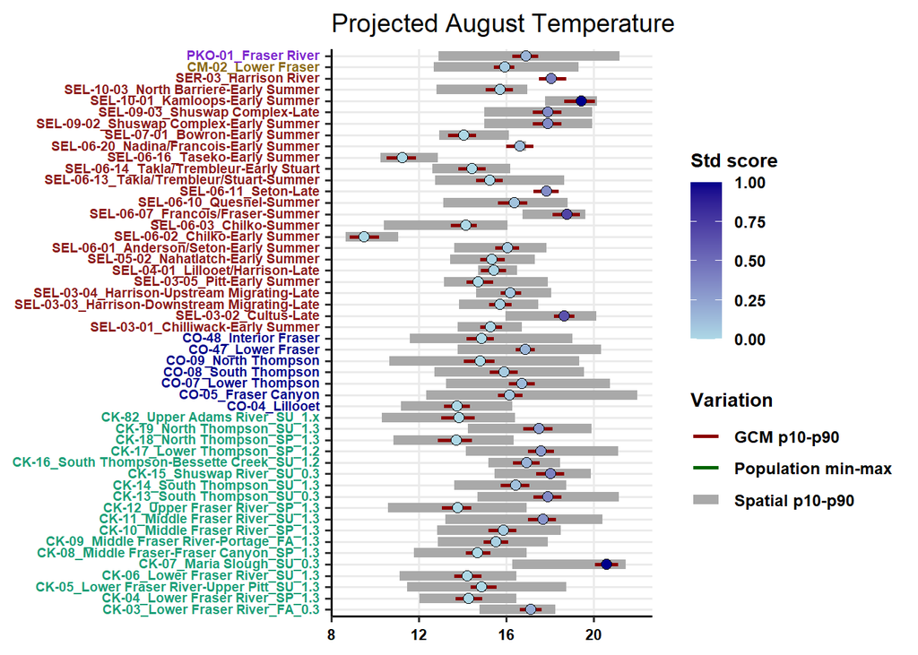

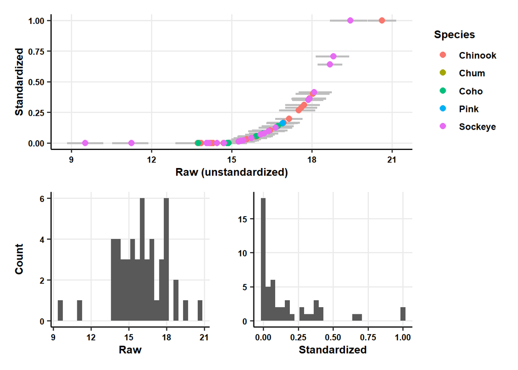

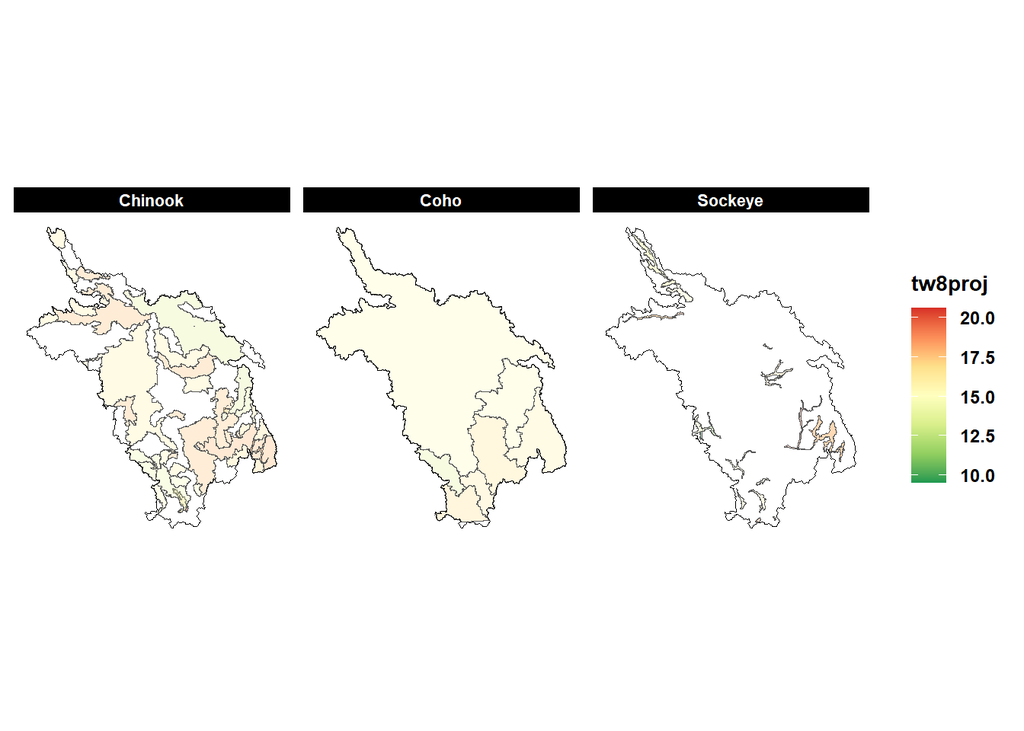

#### 85

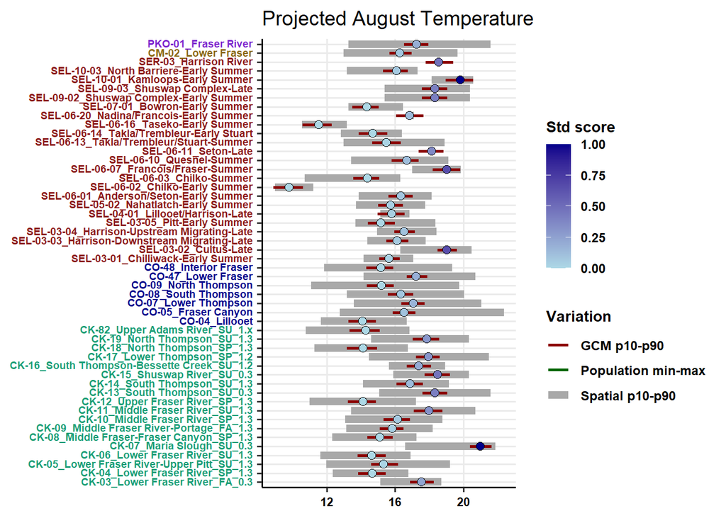

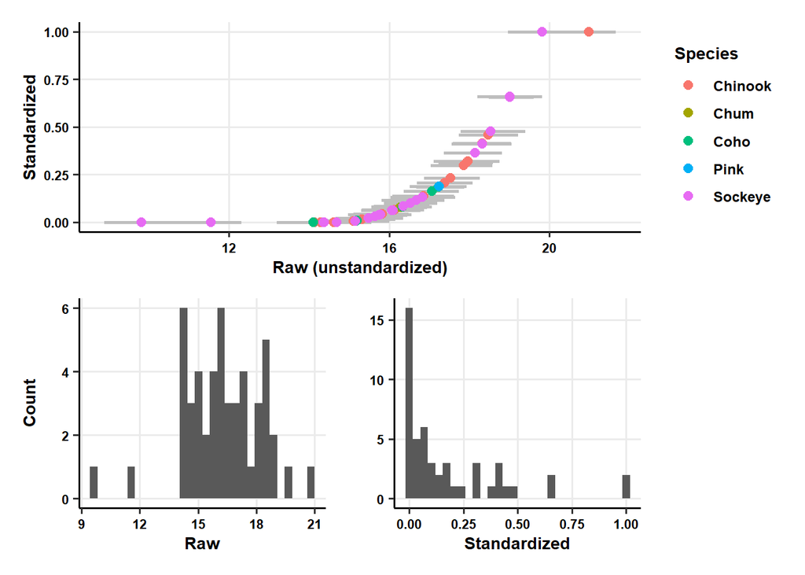

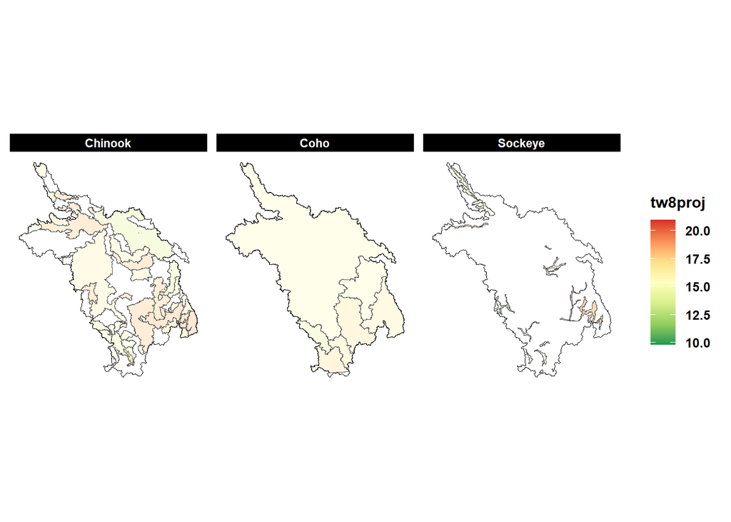

### ii. Rate of change in August temperature (tw8rate)

**Metric:** The decadal rate of increase in August mean stream temperature from a baseline period of 1981-2000 to the projection period (2041-2060 or 2081-2100) averaged over all accessible streams with modelled habitat potential contained in the CU boundary. Streams are weighted by stream segment length when calculating the average value. Projections from RCP 4.5 and 8.5 are included with an ensemble mean calculated from six global climate models.

#### 45

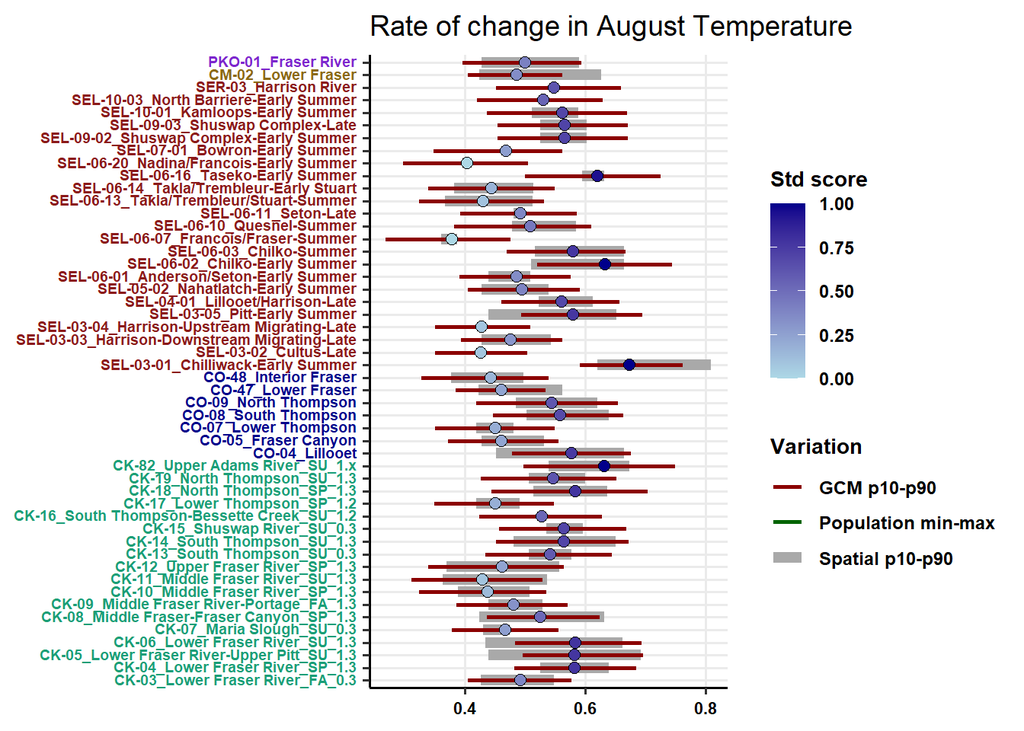

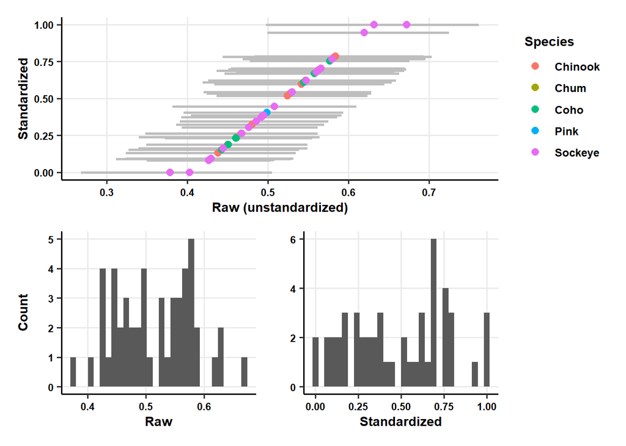

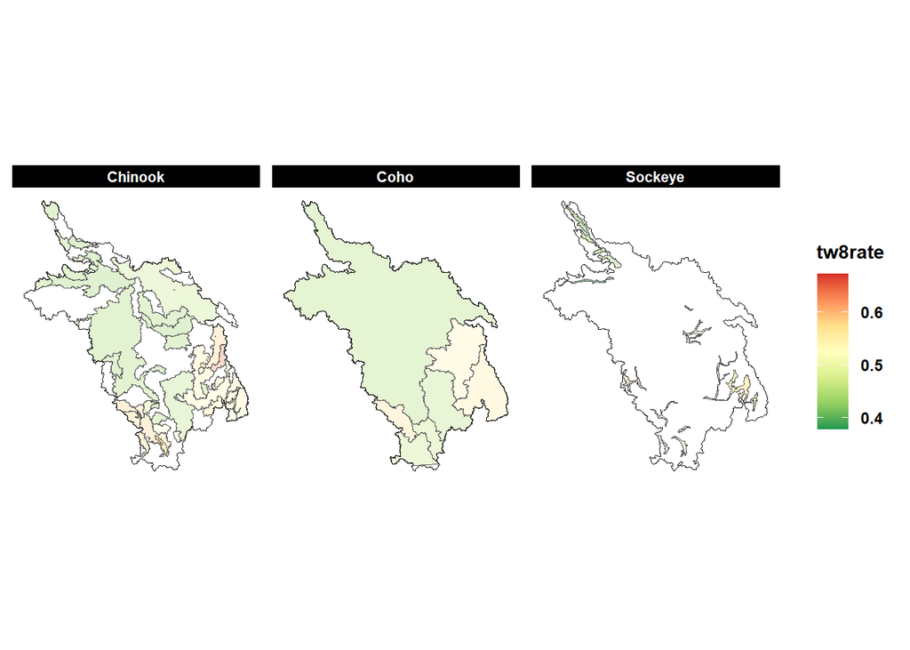

#### 85

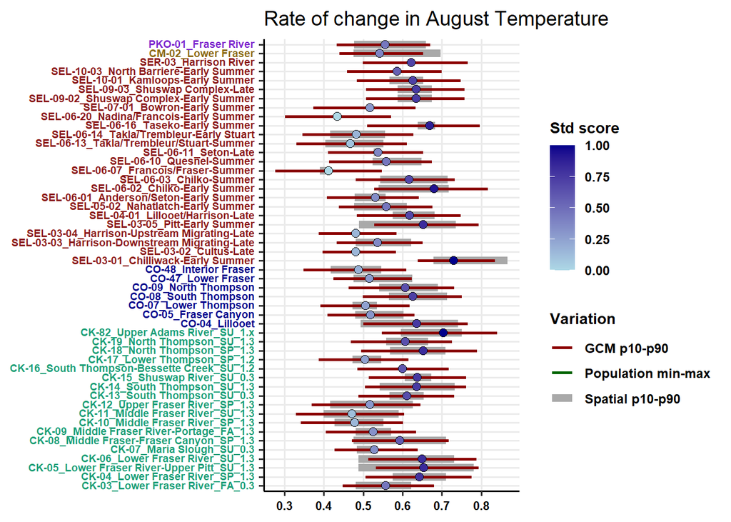

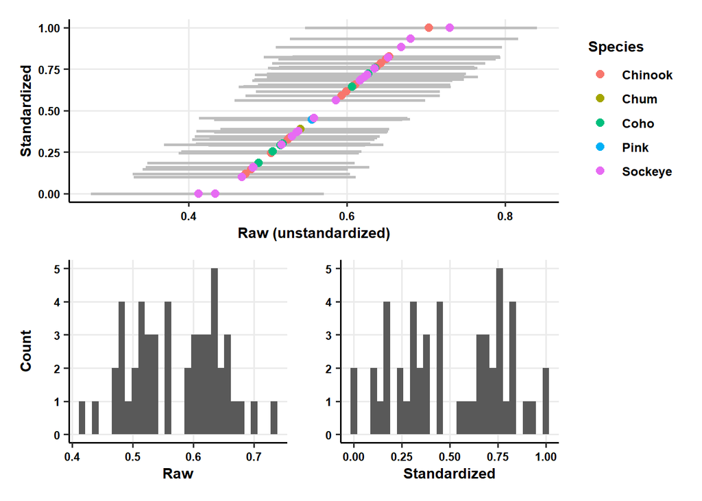

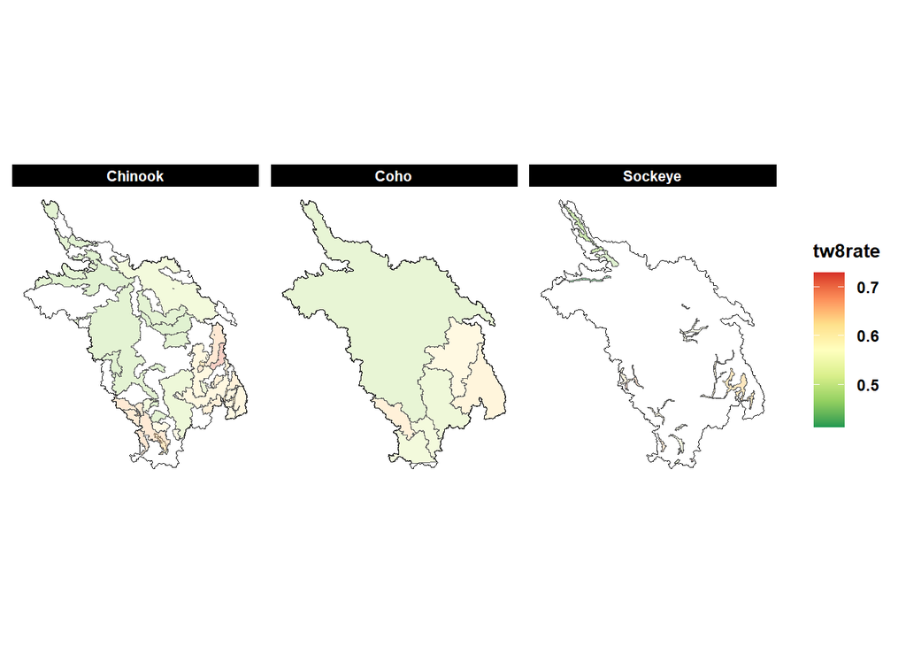

### iii. Proportional decrease in August flows (lowQpdelta)

**Metric:** The change in average August flow from a baseline period of 1981-2010 to the projection period (2041-2060 or 2081-2100), expressed as a proportion of the average historical flow and averaged over all accessible streams with modelled habitat potential contained in the CU boundary. Streams are weighted by stream segment length when calculating the average value. Projections from RCP 4.5 and 8.5 are included with an ensemble mean calculated from six global climate models.

#### 45

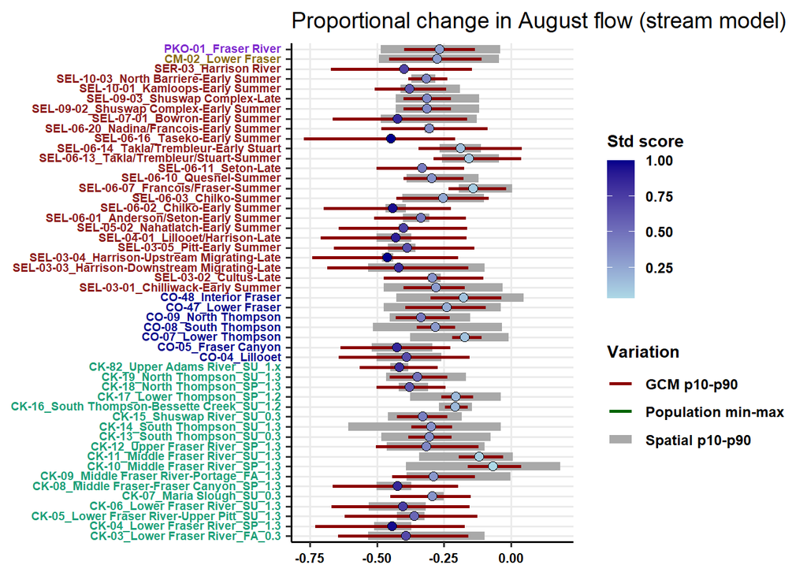

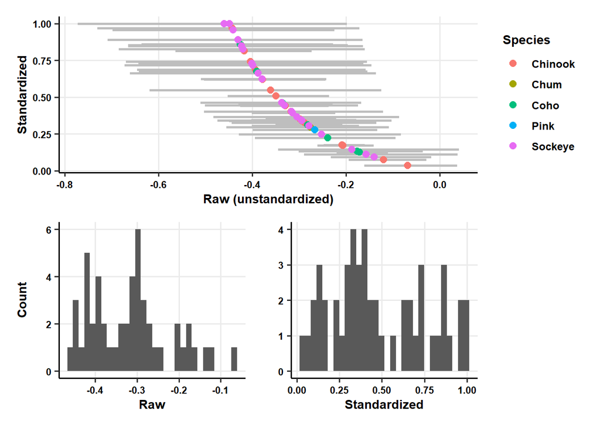

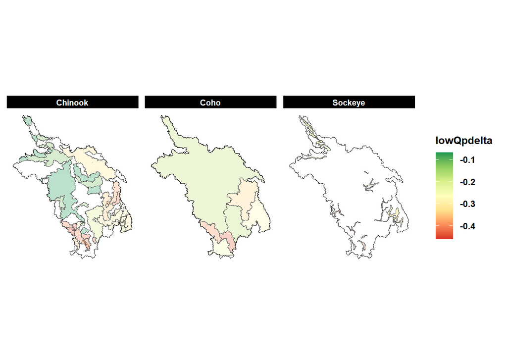

#### 85

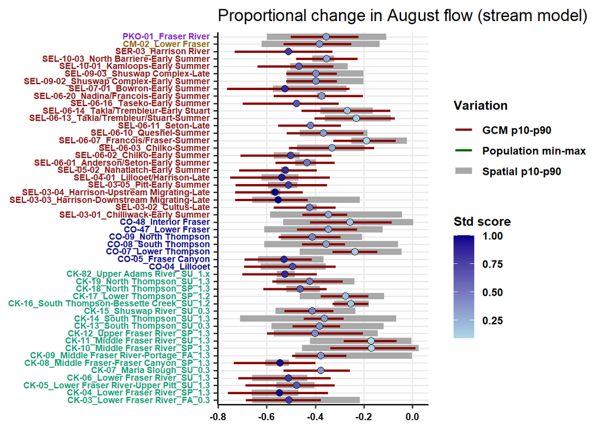

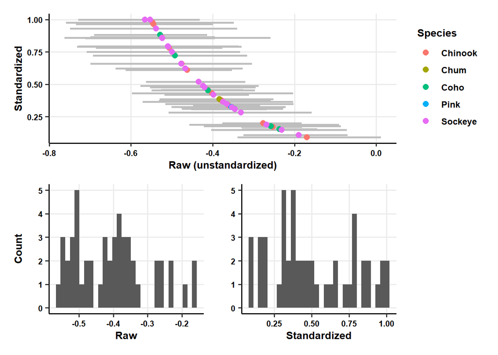

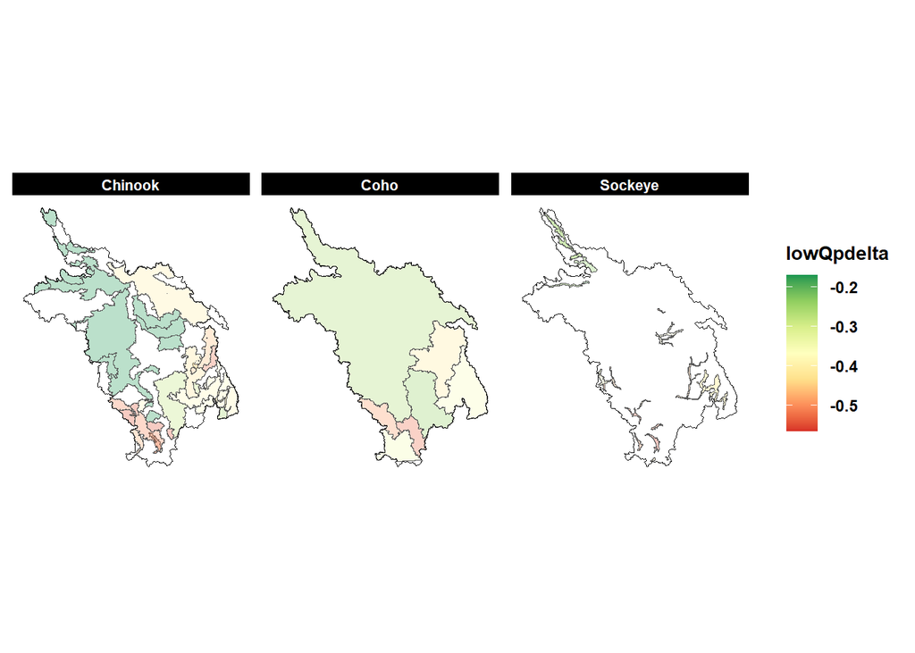

### iv. Proportional increase in November to January flows (highQpdelta)

Metric: The change in average flow for the months of November, December and January from a baseline period of 1981-2010 to the projection period (2041-2060 or 2081-2100), expressed as a proportion of the average historical flow and averaged over all accessible streams with modelled habitat potential contained in the CU boundary. Streams are weighted by stream segment length when calculating the average value. Projections from RCP 4.5 and 8.5 are included with an ensemble mean calculated from six global climate models.

#### 45

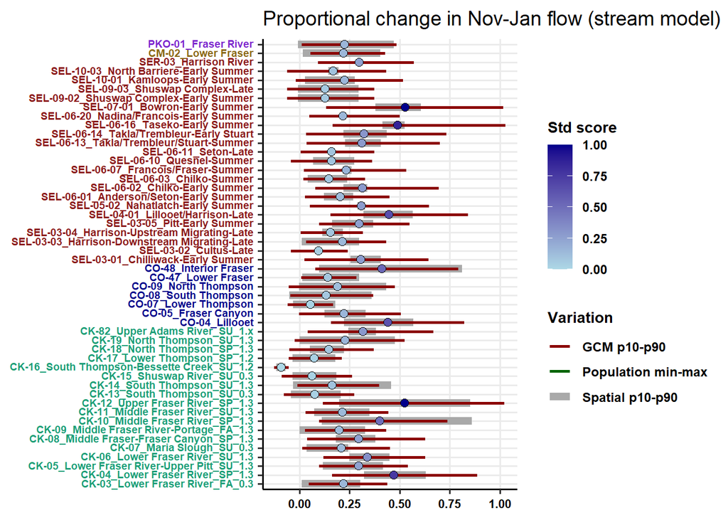

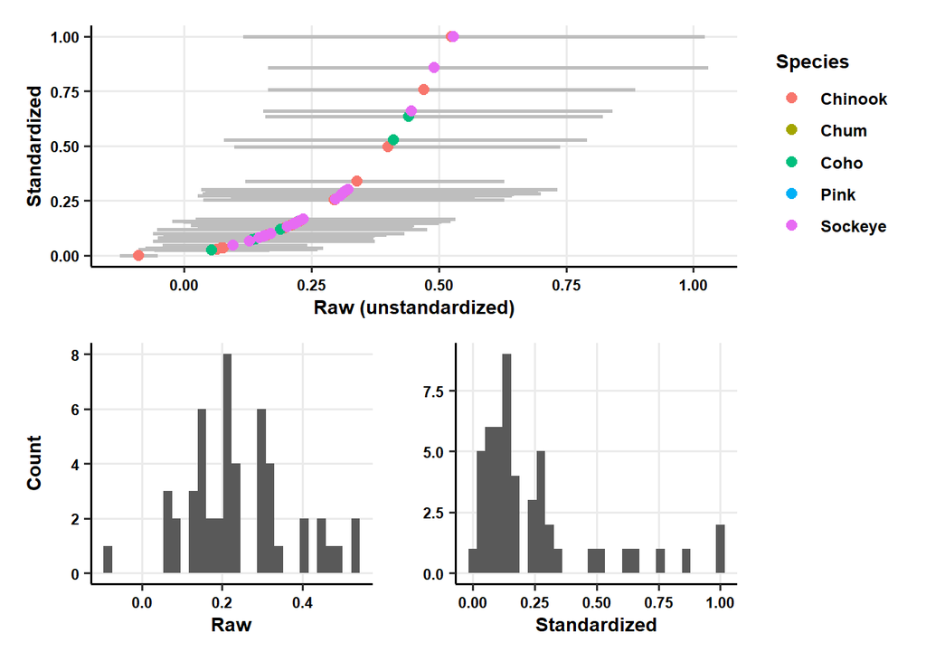

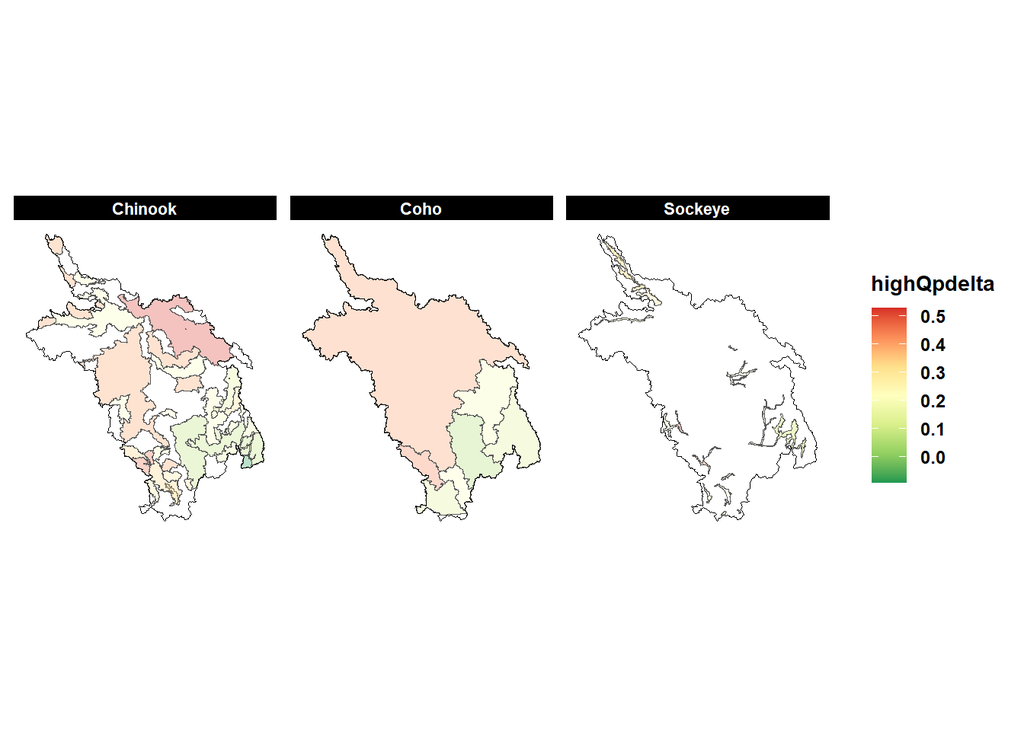

#### 85

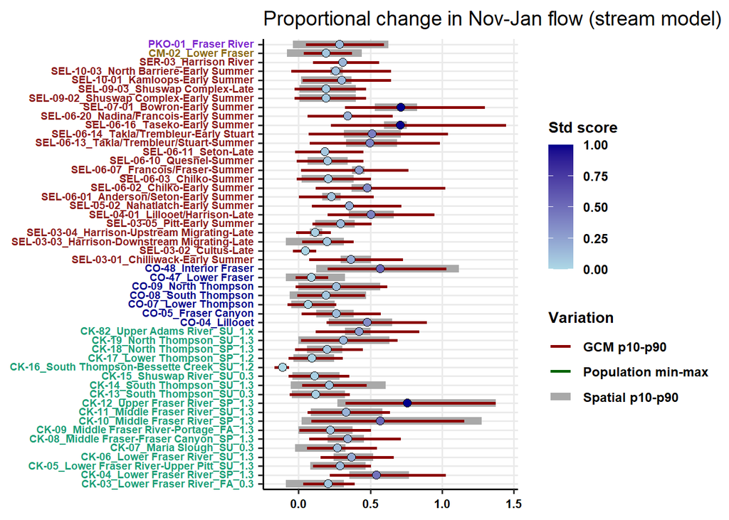

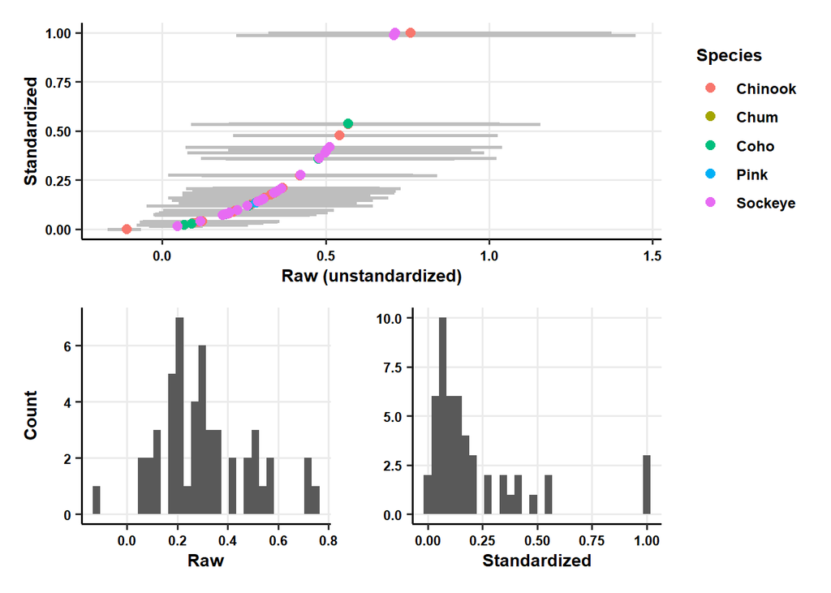

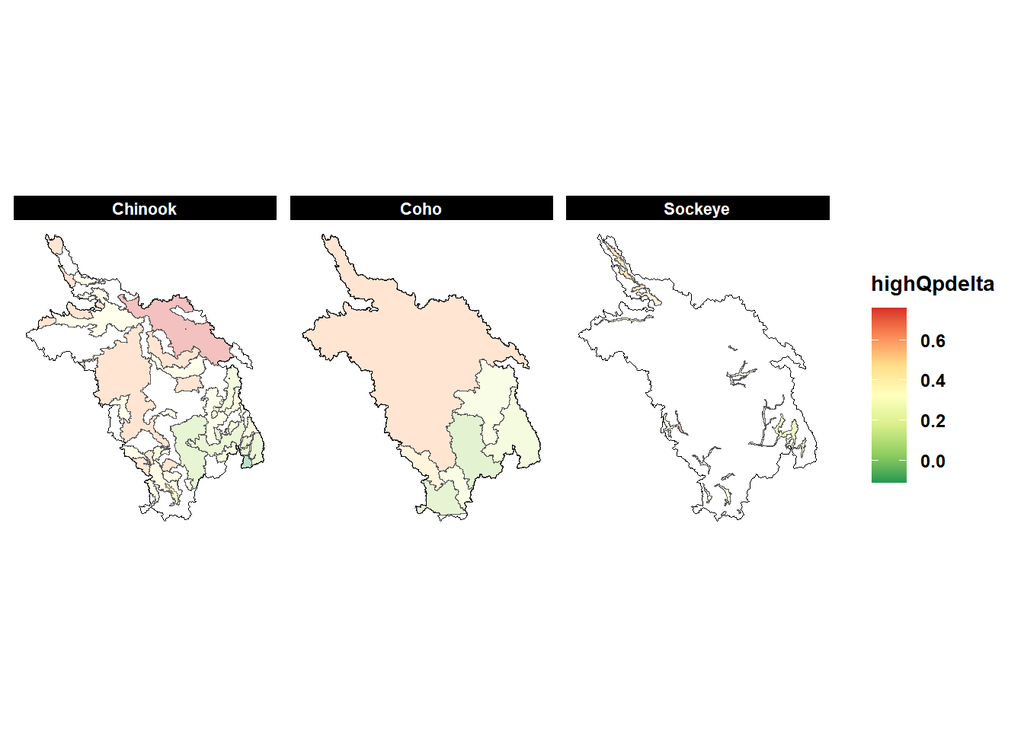

### v. Ecological Niche Model change in habitat favourability (favchange)

**Metric:** The change in habitat favourability from the baseline period (1981-2000) to the projection period (2041-2060 or 2081-2100), calculated as the difference between future and baseline favourability values and averaged over all accessible streams within the CU boundary. Habitat favourability is derived from environmental niche models (ENMs) fitted to salmon occurrence data and environmental predictors, providing a metric of environmental suitability that ranges from 0 to 1. The future favourability values use an ensemble mean of six GCMs from RCP 4.5 and 8.5 scenarios for the environmental predictors.

#### 45

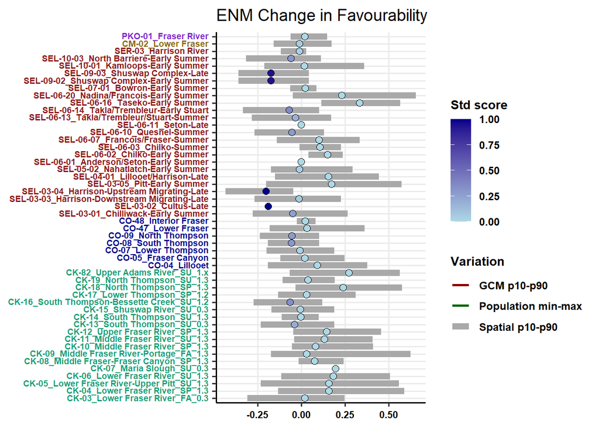

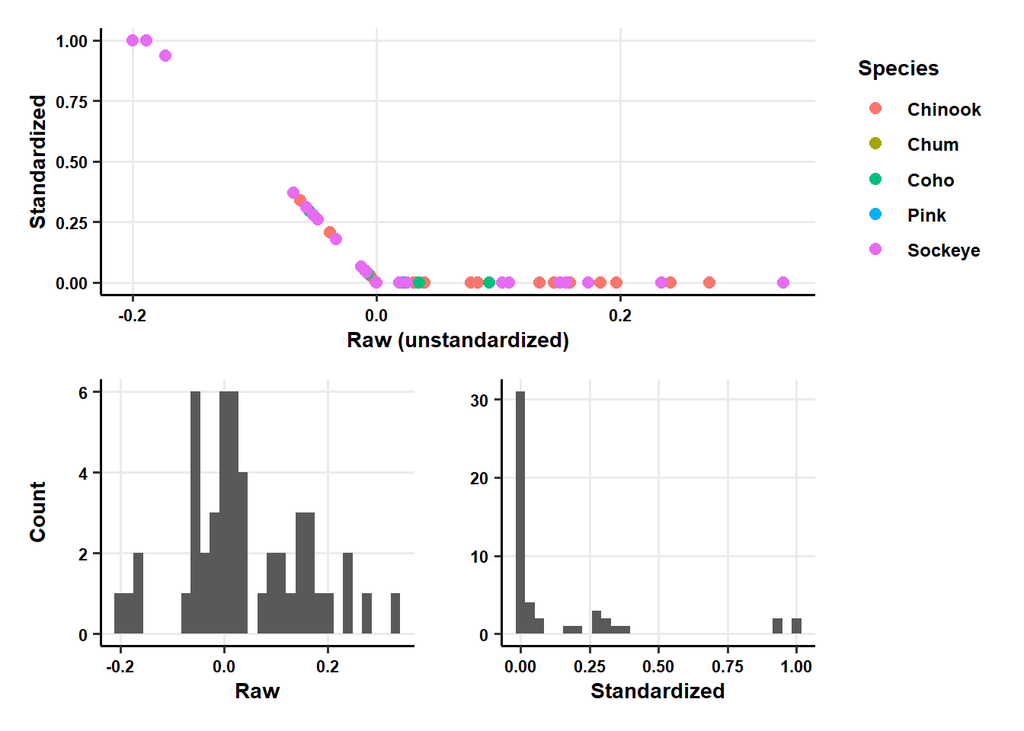

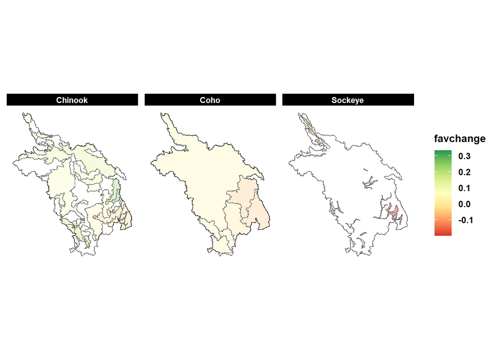

#### 85

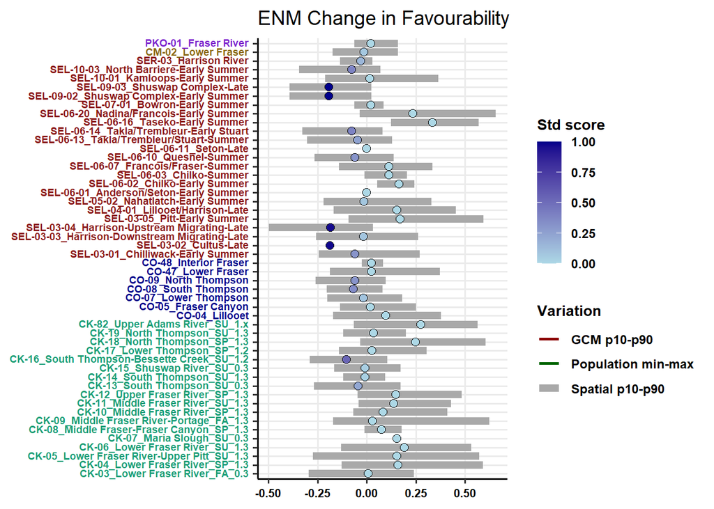

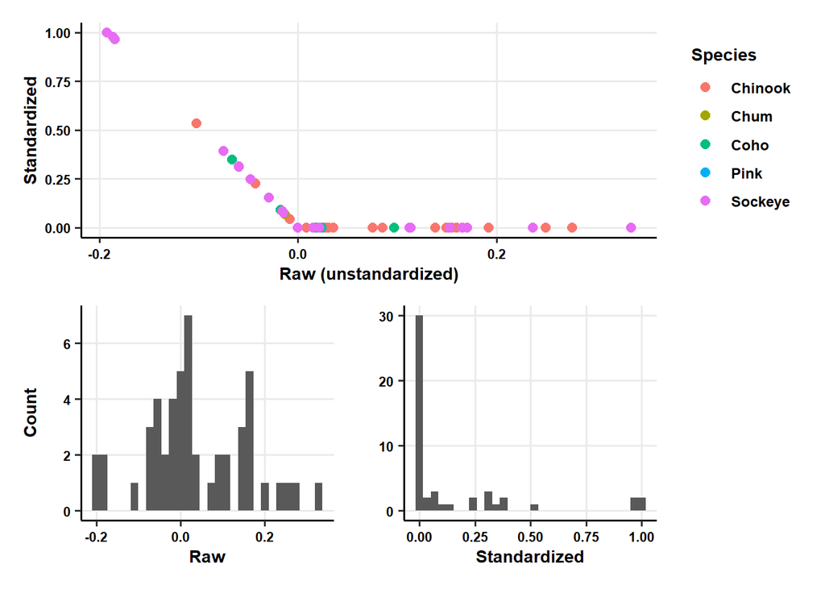

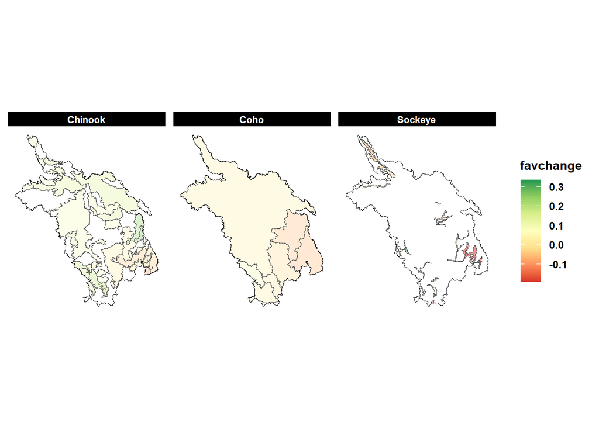